# Warm-up mini-Report: Mosquito Blood Hosts in Salt Lake City, Utah

Jordyn Blauer 2025-10-04

- ABSTRACT
- BACKGROUND
- STUDY QUESTION and HYPOTHESIS
  - Questions
  - Hypothesis
  - Prediction
- METHODS
  - Fill in 1st analysis e.g. barplots
  - Fill in 2nd analysis/plot e.g. generalized linear model
- DISCUSSION
  - Interpretation of 1st analysis (e.g. barplots)
  - Interpretation of 2nd analysis (e.g. generalized linear model)
- CONCLUSION
- REFERENCES

# ABSTRACT

West Nile Virus (WNV) can be found mainly in the Western United States. The virus can be found in animals and picked up and transferred via blood meals from mosquitoes. House finches are a common bird found in areas that WNV is present and they could be a big source of where mosquitoes pick up the virus and spread the infection. Through collection of mosquitoes in The Salt Lake City area using gravid traps and Co2 traps, female mosquitoes that have blood fed were collected and their blood meals were analyzed using PCR, followed by gel electrophoresis, MinION, and Blastn to determine positivity or negativity of WNV in the blood and what species the blood meals were taken from. By using this data run through Posit Cloud, it was determined that House finches were a major source of blood meals for mosquitoes and they had the highest positivity rates of WNV in those blood meals, meaning that the House finches were the most common and likely host for mosquitoes to pick up WNV and spread the infection, supporting our hypothesis that House finches are the most likely species to be infected with WNV and they pose a higher risk of spreading the infection via blood meals by mosquitoes.

# BACKGROUND

West Nile Virus (WNV) is a virus that is spread through the bite of a mosquito. The virus causes flu-like symptoms like fever, and headache, but in rare and severe cases it can cause damage to the central nervous system resulting in hospitalization or death (Centers). Birds of many species are found to be good hosts for WNV virus, causing mosquitoes to pick up the virus when they feed on birds who have the virus. Different species of birds have been shown to have differing days of detectable viremia. The longer the days of detectable viremia in the blood of these birds, the longer mosquitoes are able to pick up the virus when they feed on these birds (Komar et al., 2003).

In this experiment, after samples of female mosquitoes found in The Salt Lake City area were collected, the bloodmeals of the mosquitoes were extracted through smashing the mosquitoes in individual tubes, then combined with a DNA extraction/lysis buffer. The samples were then run through PCR so we could determine the presence of WNV and what species of animals the mosquitoes took bloodmeals from.

PCR is a process that is used to amplify sequences of DNA, so that there are more copies of the sample DNA to make examination of it easier (PCR). The sample DNA is combined wiht DNA extraction/lysis buffer which is many parts of DNA that is used to make more copies during the process. Once all the samples are assembled, the tubes are placed into the thermocycler machine, two of the samples in the machine are a positive sample and a negative sample that is used to compare the samples that are being tested. The machine is then allowed to run for, where it will go through different temperatures which will all have different effects on the DNA samples.

Once complete, the samples are then run through gel electrophoresis to determine if the samples contain WNV or not. On the gel, the samples are pipetting onto a starting area along with a known sample of WNV, at the starting end a negative charge is placed and at the other end a positive charge is placed. Because DNA is negatively charged it will move through the gel towards the positive end of the gel. This separates out different sizes of the DNA because larger DNA strands move slower through the gel than the smaller strands and then that DNA can be compared to the WNV strain in the gel to determine if WNV is present in the other samples.

Once it is determined what samples have WNV and which don’t it can then be determined what species of animals are found in the samples. This was done using MinION sequencing, a process that runs the samples through a device that determines the bases of DNA present so a definite sequence of DNA strains can be determined.

Once all samples are run through MinION and DNA sequences are determined, the sequences are run through BLASTn, a website database where DNA sequences can be run though in order to determine what species the DNA sequences belong to.

Once all sequences have been run through BLASTn and all the species found are recorded, the data is collected and run through Posit Cloud to further analyze the data.

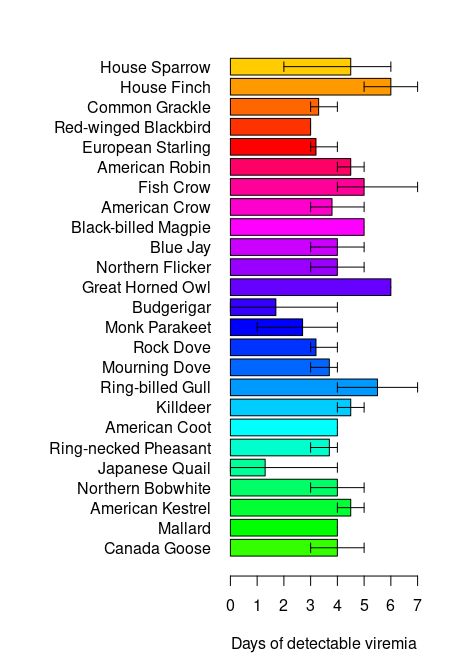

```r
# Manually transcribe duration (mean, lo, hi) from the last table column
duration <- data.frame(
  Bird = c("Canada Goose","Mallard",
           "American Kestrel","Northern Bobwhite",
           "Japanese Quail","Ring-necked Pheasant",
           "American Coot","Killdeer",
           "Ring-billed Gull","Mourning Dove",
           "Rock Dove","Monk Parakeet",
           "Budgerigar","Great Horned Owl",
           "Northern Flicker","Blue Jay",
           "Black-billed Magpie","American Crow",
           "Fish Crow","American Robin",
           "European Starling","Red-winged Blackbird",
           "Common Grackle","House Finch","House Sparrow"),
  mean = c(4.0,4.0,4.5,4.0,1.3,3.7,4.0,4.5,5.5,3.7,3.2,2.7,1.7,6.0,4.0,
           4.0,5.0,3.8,5.0,4.5,3.2,3.0,3.3,6.0,4.5),
  lo   = c(3,4,4,3,0,3,4,4,4,3,3,1,0,6,3,
           3,5,3,4,4,3,3,3,5,2),
  hi   = c(5,4,5,5,4,4,4,5,7,4,4,4,4,6,5,
           5,5,5,7,5,4,3,4,7,6)
)

# Choose some colors
cols <- c(rainbow(30)[c(10:29,1:5)])  # rainbow colors

# horizontal barplot
par(mar=c(5,12,2,2))  # wider left margin for names
bp <- barplot(duration$mean, horiz=TRUE, names.arg=duration$Bird,
              las=1, col=cols, xlab="Days of detectable viremia", xlim=c(0,7))

# add error bars
arrows(duration$lo, bp, duration$hi, bp,
       angle=90, code=3, length=0.05, col="black", xpd=TRUE)
```

# STUDY QUESTION and HYPOTHESIS

## Questions

Are House finches the most likely species to be infected with WNV and pass on the infection?

## Hypothesis

House finches are the most likely species to be infected with WNV and they pose a higher risk of spreading the infection via blood meals by mosquitoes

## Prediction

If House finches are the most likely species to have WNV, we predict that mosquitoes caught in a certain area where House finches are present, will have fed from House finches more than other species, causing there to be higher rates of WNV in the House finches.

# METHODS

To begin the experiment, first, female mosquitoes were caught from the Salt Lake City area using gravid traps and CO2 traps. Once collected, the blood was extracted from the mosquitoes by smashing the mosquitoes and then run through PCR in order to amplify the DNA.

To extract the blood, the mosquitoes were first smashed in their own individual tubes and the tubes were labeled and recorded. The smashed mosquitoes were then combined with 100 μL of DNA extraction/lysis buffer.

Next, the smashes mosquitoes and their blood meals were ran through PCR to amplify the DNA in the samples to then be tested for the presence of WNV, this was done by pipetting reagents into the individual tubes, setting up a positive and negative sample, along with the other samples that are being tested. Once the thermocycler was setup, the samples were placed into the machine and allowed to run.

The next step was to sequence the DNA. The amplified samples were then run through gel electrophoresis to determine the presence of WNV in the samples. The presence and absence of WNV was recorded for each sample.

This was done by taking the samples that were amplified through the PCR and then sequenced using MinION Sequencing. The sequenced DNA from all the samples were then recorded and the sequences were analyzed using BLASTn analysis to find what kind of host species were found in the blood meals. All of the species found in the BLASTn were recorded.

Lastly, the data we collected was assembled using Posit Cloud to show all of the species that were found in the blood meals and how many blood meals were found taken from all species found, as well as if WNV was detected or not. Then statistical tests were performed to find if the most common species found in the blood meals, the House finch, was correlated to increase the chance of WNV being detected at a certain location and if the amount of House finches were found to increase the amount of infection.

## Fill in 1st analysis e.g. barplots

In these bar plots, the number of mosquito blood meals were compared from each of the found host species between sites with no WNV-positive pools and sites with one or more WNV-positive pools. The bar plot helps visualize this data because the bar plots show what species were found, the amount of blood meals taken from the found species, and whether or not WNV was detected.

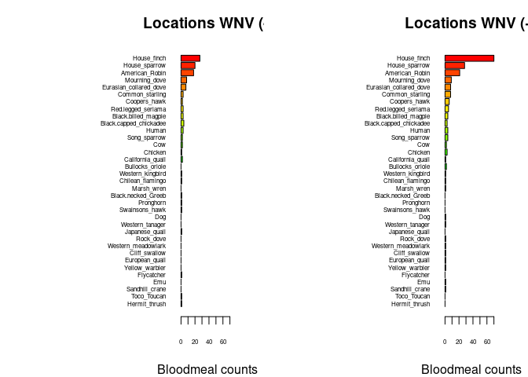

```r
## import counts_matrix: data.frame with column 'loc_positives' (0/1) and host columns 'host_*'
counts_matrix <- read.csv("./bloodmeal_plusWNV_for_BIOL3070.csv")

## 1) Identify host columns
host_cols <- grep("^host_", names(counts_matrix), value = TRUE)

if (length(host_cols) == 0) {
  stop("No columns matching '^host_' were found in counts_matrix.")
}

## 2) Ensure loc_positives is present and has both levels 0 and 1 where possible
counts_matrix$loc_positives <- factor(counts_matrix$loc_positives, levels = c(0, 1))

## 3) Aggregate host counts by loc_positives
agg <- stats::aggregate(
  counts_matrix[, host_cols, drop = FALSE],
  by = list(loc_positives = counts_matrix$loc_positives),
  FUN = function(x) sum(as.numeric(x), na.rm = TRUE)
)

## make sure both rows exist; if one is missing, add a zero row
need_levels <- setdiff(levels(counts_matrix$loc_positives), as.character(agg$loc_positives))
if (length(need_levels)) {
  zero_row <- as.list(rep(0, length(host_cols)))
  names(zero_row) <- host_cols
  for (lv in need_levels) {
    agg <- rbind(agg, c(lv, zero_row))
  }
  ## restore proper type
  agg$loc_positives <- factor(agg$loc_positives, levels = c("0","1"))
  ## coerce numeric host cols (they may have become character after rbind)
  for (hc in host_cols) agg[[hc]] <- as.numeric(agg[[hc]])
  agg <- agg[order(agg$loc_positives), , drop = FALSE]
}

## 4) Decide species order (overall abundance, descending)
overall <- colSums(agg[, host_cols, drop = FALSE], na.rm = TRUE)
host_order <- names(sort(overall, decreasing = TRUE))
species_labels <- rev(sub("^host_", "", host_order))  # nicer labels

## 5) Build count vectors for each panel in the SAME order
counts0 <- rev(as.numeric(agg[agg$loc_positives == 0, host_order, drop = TRUE]))
counts1 <- rev(as.numeric(agg[agg$loc_positives == 1, host_order, drop = TRUE]))

## 6) Colors: reuse your existing 'cols' if it exists and is long enough; otherwise generate
if (exists("cols") && length(cols) >= length(host_order)) {
  species_colors <- setNames(cols[seq_along(host_order)], species_labels)
} else {
  species_colors <- setNames(rainbow(length(host_order) + 10)[seq_along(host_order)], species_labels)
}

## 7) Shared x-limit for comparability
xmax <- max(c(counts0, counts1), na.rm = TRUE)
xmax <- if (is.finite(xmax)) xmax else 1
xlim_use <- c(0, xmax * 1.08)

## 8) Plot: two horizontal barplots with identical order and colors
op <- par(mfrow = c(1, 2),
          mar = c(4, 12, 3, 2),  # big left margin for species names
          xaxs = "i")           # a bit tighter axis padding

## Panel A: No WNV detected (loc_positives = 0)
barplot(height = counts0,
        names.arg = species_labels,
        cex.names = .5,
        cex.axis = .5,
        col = rev(unname(species_colors[species_labels])),
        horiz = TRUE,
        las = 1,
        xlab = "Bloodmeal counts",
        main = "Locations WNV (-)",
        xlim = xlim_use)

## Panel B: WNV detected (loc_positives = 1)
barplot(height = counts1,
        names.arg = species_labels,
        cex.names = .5,
        cex.axis = .5,
        col = rev(unname(species_colors[species_labels])),
        horiz = TRUE,
        las = 1,
        xlab = "Bloodmeal counts",
        main = "Locations WNV (+)",
        xlim = xlim_use)
```

```r
par(op)

## Keep the colors mapping for reuse elsewhere
host_species_colors <- species_colors
```

## Fill in 2nd analysis/plot e.g. generalized linear model

The first statistical test is a logistic regression model it shows whether there is an association between House finches and being positive for WNV.

The second statistical test is a linear regression model. It tests whether the number of House finch blood meals predicts the WNV positivity rate.

```r
# second-analysis-or-plot, glm with house finch alone against binary +/_
glm1 <- glm(loc_positives ~ host_House_finch,
            data = counts_matrix,
            family = binomial)
summary(glm1)
```

```
##
## Call:
## glm(formula = loc_positives ~ host_House_finch, family = binomial,
##     data = counts_matrix)
##
## Coefficients:
##                  Estimate Std. Error z value Pr(>|z|)
## (Intercept)       -0.1709     0.1053  -1.622   0.1047
## host_House_finch   0.3468     0.1586   2.187   0.0287 *
## ---
## Signif. codes:  0 '***' 0.001 '**' 0.01 '*' 0.05 '.' 0.1 ' ' 1
##
## (Dispersion parameter for binomial family taken to be 1)
##
##     Null deviance: 546.67  on 394  degrees of freedom
## Residual deviance: 539.69  on 393  degrees of freedom
## AIC: 543.69
##
## Number of Fisher Scoring iterations: 4
```

```r
#glm with house-finch alone against positivity rate
glm2 <- glm(loc_rate ~ host_House_finch,
            data = counts_matrix)
summary(glm2)
```

```
##
## Call:
## glm(formula = loc_rate ~ host_House_finch, data = counts_matrix)
##
## Coefficients:
##                  Estimate Std. Error t value Pr(>|t|)
## (Intercept)      0.054861   0.006755   8.122 6.07e-15 ***
## host_House_finch 0.027479   0.006662   4.125 4.54e-05 ***
## ---
## Signif. codes:  0 '***' 0.001 '**' 0.01 '*' 0.05 '.' 0.1 ' ' 1
##
## (Dispersion parameter for gaussian family taken to be 0.01689032)
##
##     Null deviance: 6.8915  on 392  degrees of freedom
## Residual deviance: 6.6041  on 391  degrees of freedom
##   (2 observations deleted due to missingness)
## AIC: -484.56
##
## Number of Fisher Scoring iterations: 2
```

# DISCUSSION

## Interpretation of 1st analysis (e.g. barplots)

The bar plots show the amount of blood meals that were found to be taken from each of the individual host species found in the experiment. It was found that the mosquitoes took most of their blood meals from House finches followed by House sparrows. The panel to the left, labeled with a “-,” signifies that WNV was not detected in these blood meals.The panel to the right, labeled with a “+,” signifies that WNV was detected in these bloodmeals. Based on the plot, it can be determined that House finches had the most amount of blood meals taken from them and from them they had the highest rates of both being positive for WNV and being negative for WNV.

These bar plots help support our hypothesis of House finches are the most likely species to be infected with WNV and they pose a higher risk of spreading the infection via blood meals by mosquitoes because it tells us that the House finches were the main species the mosquitoes took blood meals from and were positive for WNV.

## Interpretation of 2nd analysis (e.g. generalized linear model)

The first statistical test produced a p-value of 0.0287, indicating that the association between House finch presence and WNV positivity is statistically significant. This means that areas with more House finch blood meals taken are significantly more likely to be positive for WNV.

The second statistical test produced a p-value of 4.54 × 10⁻⁵, which is highly significant. This shows that greater numbers of House finch blood meals are significantly correlated with higher rates of WNV positivity in the area.

These analyses support our hypothesis that House finches are the most likely species to be infected with WNV and they pose a higher risk of spreading the infection via blood meals by mosquitoes. The first statistical test showed that House Finch blood meals were significantly more likely to have WNV-positive mosquito pools. This shows that House Finches contribute to the rate of infection of WNV in the area because mosquitoes are more likely to pick up the virus from them. The second statistical test further showed that the number of House Finch blood meals was significantly correlated with higher WNV positivity rates, indicating that finches may increase WNV infections in the Salt Lake City area that they were collected from.

Although these analysis and plots support the hypothesis, there is a limitation that this experiment only tests mosquitoes collected in The Salt Lake City area. If data were to be collected from other locations around The United States, it could show that different species, other than House finches, are found to play a bigger role in spreading WNV.

# CONCLUSION

In conclusion, the findings from the data conclude that House finches are the most likely species to be infected with WNV due to the data showing that House finches had highest rates of WNV and highest rates of mosquitoes taking blood meals from them and they pose a higher risk of passing on infection due to the House finches having one of the longest rates of detectable viremia, an they are the most likely species to be infected.

# REFERENCES

1. Komar N, Langevin S, Hinten S, Nemeth N, Edwards E, Hettler D, Davis B, Bowen R, Bunning M. Experimental infection of North American birds with the New York 1999 strain of West Nile virus. Emerg Infect Dis. 2003 Mar;9(3):311-22. https://doi.org/10.3201/eid0903.020628
2. ChatGPT. OpenAI, version Jan 2025. Used as a reference for functions such as plot() and to correct syntax errors. Accessed 2025-10-04.
3. Centers for Disease Control and Prevention. (n.d.). About West Nile. Centers for Disease Control and Prevention. https://www.cdc.gov/west-nile-virus/about/index.html
4. Polymerase chain reaction (PCR) fact sheet. Genome.gov. (n.d.). https://www.genome.gov/about-genomics/fact-sheets/Polymerase-Chain-Reaction-Fact-Sheet